# academic_mastery

Kevin Gilds, MPA

June 14, 2016

# Academic Mastery

The Academic Mastery questions gauge a student’s attitude towards school and education. Questions that measure Academic Mastery include the following.

- It’s important to me that I improve my skills this year in school
- It’s important to me that I really understand my class work
- Learning at school is important to me
- One of my goals in school is to learn as much as I can
- The things I am learning in school will help me later in life

The number of pre and post survey that could be matched is **74**, and the percent of students with a successful outcome is **94.59%**

1. The number of students achieving the academic engagement outcome at a high level is **69**
2. The number of students who did not achieve outcome at high level but increased their outcome score is **1**

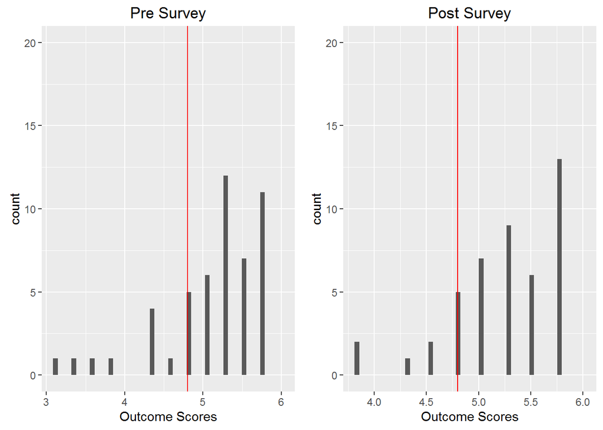

The improvement in outcome scores is graphically represented below.

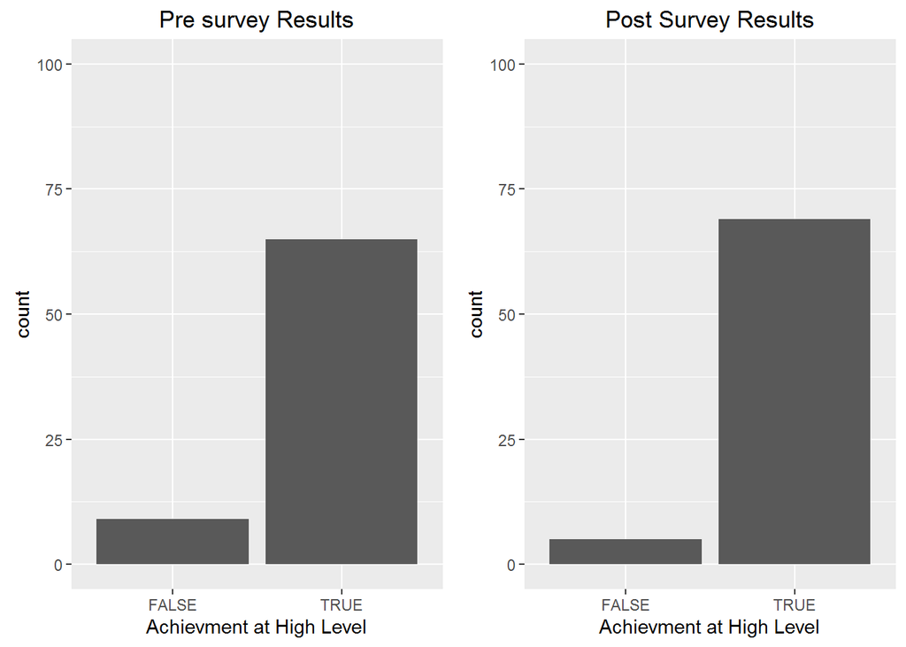

The percent of students who went from low achievement to high achievement is **10.81%** The number of students who had the opportunity to improve their academic engagement outcome score is **35**, and their mean increase in outcome score is **0.1234286**

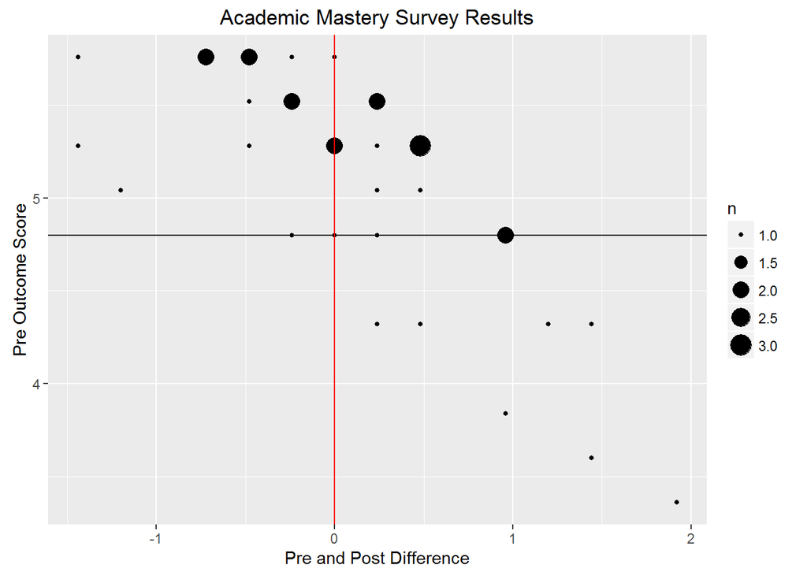

### Statistical Tests

Two statistical tests were administered on the matched survey results the Wilcox test and Cohen’s D test.

The outcome distributions did not approximate a normal distribution, thus a Wilcox.test was administered and the results show that the difference between the pre and post outcome scores are not significant at .05 level.

Wilcoxon signed rank test with continuity correction: `am_2016$Pre` and `am_2016$Post`

| Test statistic | P value | Alternative hypothesis |
| --- | --- | --- |
| 619.5 | 0.07266 | less |

```
##
## Cohen's d
##
## d estimate: -0.1923114 (negligible)
## 95 percent confidence interval:
##        inf        sup
## -0.5202041  0.1355812
```